# SVM

Eric

8 février 2019

But de l’étude:

On souhaite établir un modèle de prédiction de la clairance à partir de descripteurs géométrique et physico-chimiques de petits composés. Nous allons utiliser la méthode SVM pour répondre à la question.

## Preparation du jeu de données

Présentation des données

```
                      Noms   CI a_base BCUT_PEOE_1
1                Abacavir  0.47      0  -0.6517531
2                 Acipimox 0.25      0  -0.5428498
3               Acyclovir  0.17      0  -0.4743490
4                Alanine_L 0.30      1  -0.5439147
5               Alfentanil 0.75      1  -0.4687364
6 Aminohippuric_acid_PAH   0.47      0  -0.6177712
```

```
Nombre de descripteurs (médicaments)
                                 138
```

```
Nombre de molecules
                 90
```

Verification des descripteurs à variances nulles ou proche de 0

```
 [1] "BCUT_PEOE_1"    "BCUT_PEOE_2"    "BCUT_SLOGP_2"   "BCUT_SMR_1"
 [5] "BCUT_SMR_2"     "b_1rotR"        "GCUT_PEOE_0"    "GCUT_SMR_0"
 [9] "GCUT_SMR_2"     "PEOE_VSA_FPOS"  "Mv"             "nTB"
[13] "HNar"           "MSD"            "PW3"            "PW4"
[17] "PJI2"           "X3A"            "X4A"            "X3Av"
[21] "X5Av"           "MATS1m"         "MATS2m"         "MATS2p"
[25] "GATS2e"         "GATS2p"         "JGI2"           "JGI4"
[29] "JGI6"           "SHP2"           "SPAM"           "FDI"
[33] "nR.Cp"          "nArCONHR"       "nRC.N"          "nArC.N"
[37] "nN.N"           "ntH.Thiophenes" "nThiophenes"    "nPyridazines"
[41] "nPyrazines"     "C.015"          "C.020"          "C.034"
[45] "N.070"          "N.073"          "N.076"          "F.081"
[49] "Cl.090"         "S.109"          "P.117"          "Depressant.50"
```

```
Nombre de descripteurs restants
                             86
```

Verification des descripteurs corrélées a plus de 0.8

```
 [1] 19 62 13 61 22 48 79 38 34 53
```

```
Nombres de descripteurs restant
                             76
```

Verification des descripteurs avec des données abérantes

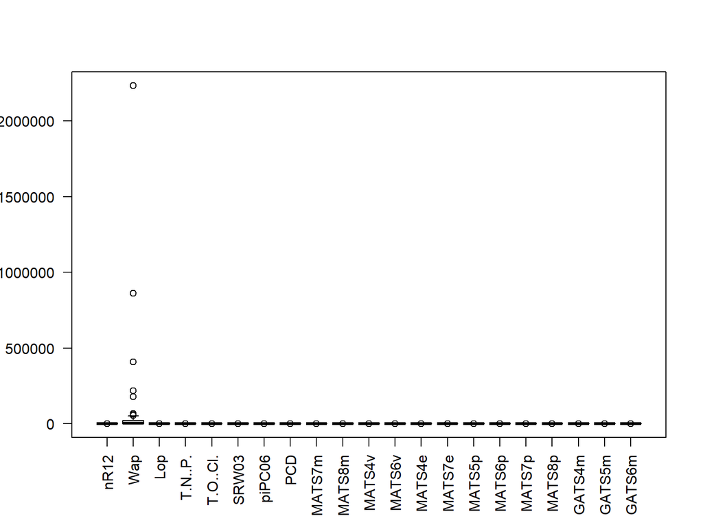

Après suppression du descripteur “Wap”

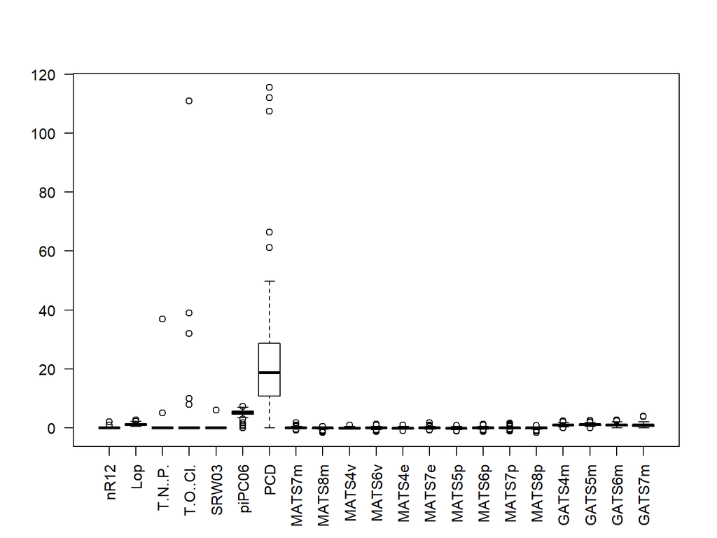

```
Nombres de descripteurs restant
                             75
```

Normalisation des descripteurs

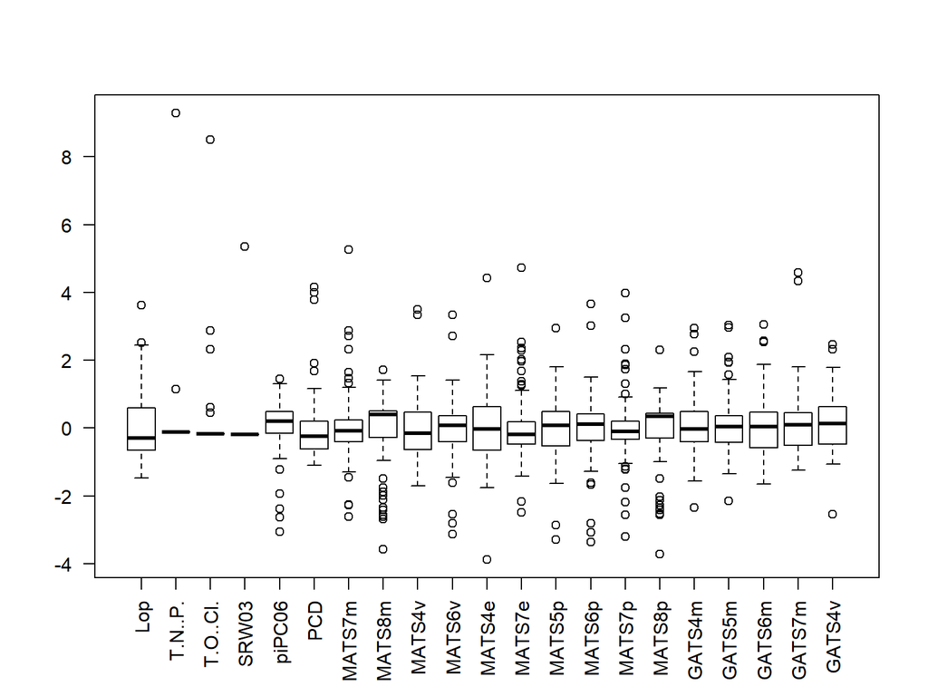

Visualisation des données grâce à une remise à l’échelle des donnée.(MDS)

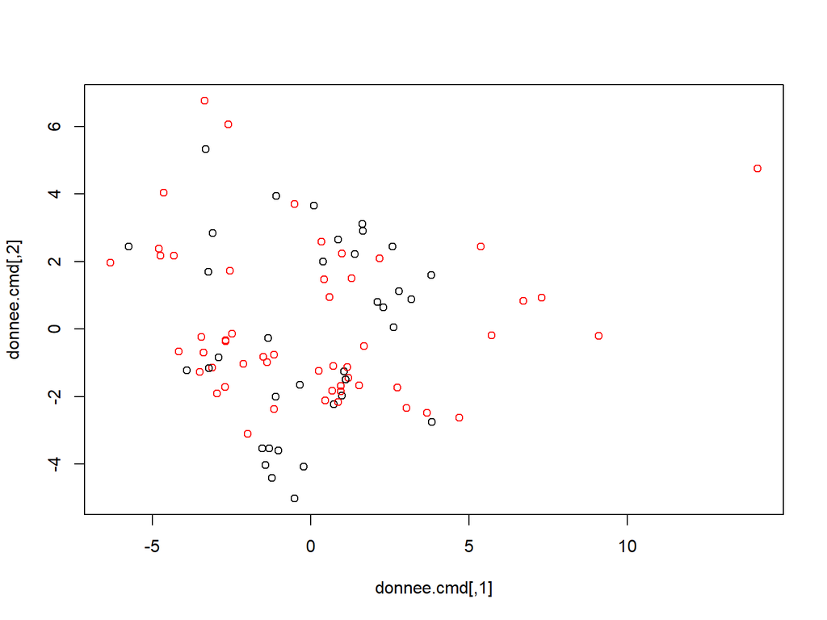

Visualisation des données grâce à une analyse des principaux composants

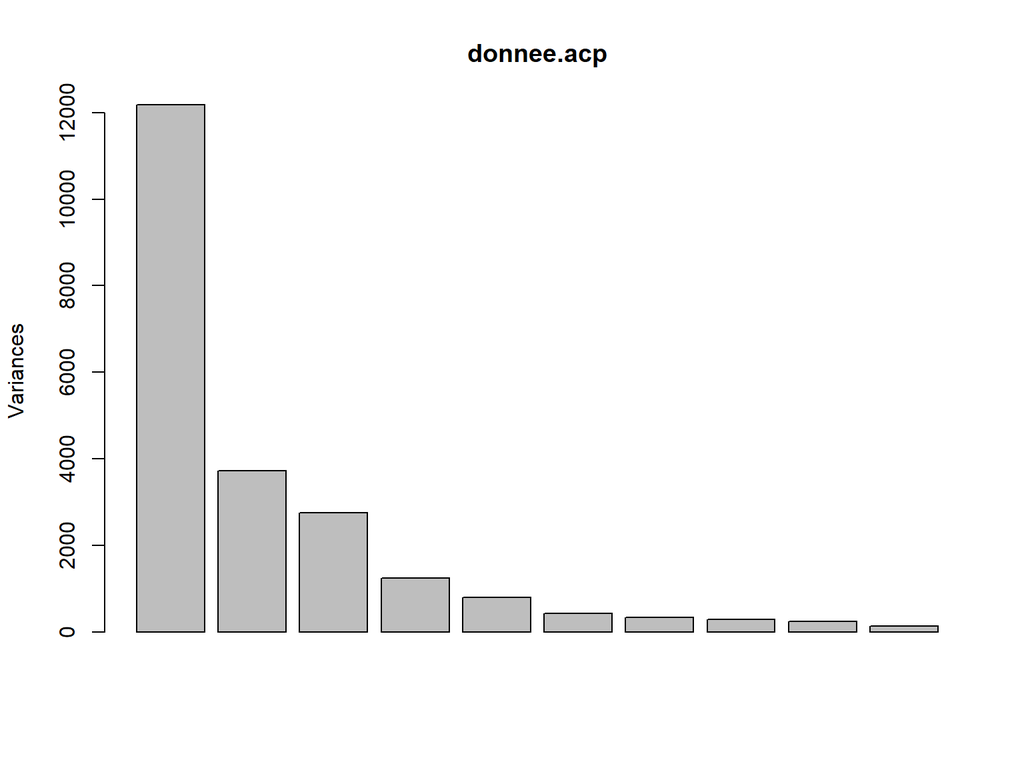

## Création des modèles d’apprentissage et de test

Création d’un modèle d’apprentissage

```
   a_base b_max1len GCUT_SLOGP_0 GCUT_SLOGP_3
30      0         2   -0.8735171     1.604797
68      0         7   -1.1654736     3.026012
11      0         2   -0.9903958     2.748619
61      0         4   -1.3490000     2.329814
45      1         5   -2.2596524     2.526990
6       0         2   -1.4896291     2.196790
```

```
individus dans échantillon d'apprentissage
                                        60
```

Création d’un modèle de test

```
   a_base b_max1len GCUT_SLOGP_0 GCUT_SLOGP_3
1       0         2   -1.3352119     2.689577
4       1         2   -2.2348113     1.743887
9       0         4   -0.9486618     3.396952
10      0         5   -1.4897290     2.614374
13      1         3   -2.2602122     3.673782
14      0         3   -1.4899809     2.765061
```

```
individus dans échantillon test
                             30
```

Verification de la répartition des individus dans nos échantillons (test d’homogénéité)

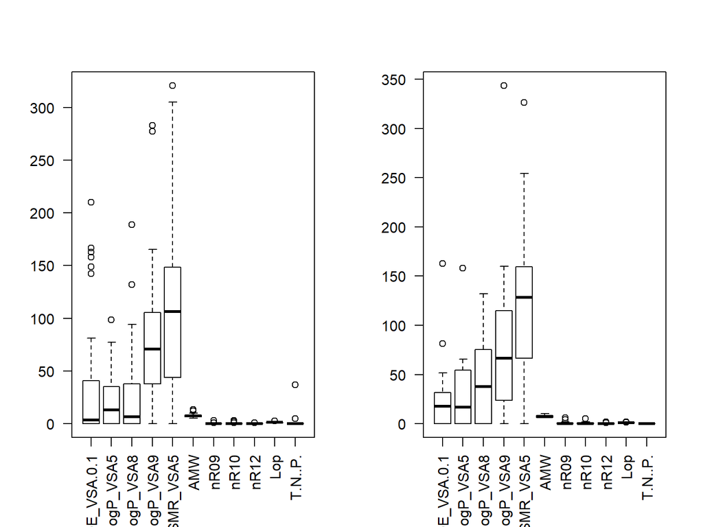

## Verification des résultats de prédictions avec différents paramètres

Résultats obtenus pour le modele d’apprentissage avec kernel lineaire

```
Call:
svm(formula = CI_class ~ ., data = mat.App, type = "C-classification",
    kernel = "linear")


Parameters:
   SVM-Type:  C-classification
 SVM-Kernel:  linear
       cost:  1
      gamma:  0.01369863

Number of Support Vectors:  44

 ( 21 23 )


Number of Classes:  2

Levels:
 grand petit
```

```
       observe
predit  grand petit
  grand    25     1
  petit     1    33
```

Résultats obtenus pour le modele d’apprentissage avec kernel polynomial

```
Call:
svm(formula = CI_class ~ ., data = mat.App, type = "C-classification",
    kernel = "polynomial")


Parameters:
   SVM-Type:  C-classification
 SVM-Kernel:  polynomial
       cost:  1
     degree:  3
      gamma:  0.01369863
     coef.0:  0

Number of Support Vectors:  58

 ( 26 32 )


Number of Classes:  2

Levels:
 grand petit
```

```
       observe
predit  grand petit
  grand    14     0
  petit    12    34
```

Résultats obtenus pour le modele d’apprentissage avec kernel radial

```
Call:
svm(formula = CI_class ~ ., data = mat.App, type = "C-classification",
    kernel = "radial")


Parameters:
   SVM-Type:  C-classification
 SVM-Kernel:  radial
       cost:  1
      gamma:  0.01369863

Number of Support Vectors:  57

 ( 26 31 )


Number of Classes:  2

Levels:
 grand petit
```

```
       observe
predit  grand petit
  grand    21     0
  petit     5    34
```

Résultats obtenus pour le modele d’apprentissage avec kernel sigmoide

```
Call:
svm(formula = CI_class ~ ., data = mat.App, type = "C-classification",
    kernel = "sigmoid")


Parameters:
   SVM-Type:  C-classification
 SVM-Kernel:  sigmoid
       cost:  1
      gamma:  0.01369863
     coef.0:  0

Number of Support Vectors:  57

 ( 26 31 )


Number of Classes:  2

Levels:
 grand petit
```

```
       observe
predit  grand petit
  grand     7     4
  petit    19    30
```

Conclusion, le modele linéaire semble plus approprié

```
Call:
svm(formula = CI_class ~ ., data = mat.App, type = "C-classification",
    kernel = "linear", cost = 2)


Parameters:
   SVM-Type:  C-classification
 SVM-Kernel:  linear
       cost:  2
      gamma:  0.01369863

Number of Support Vectors:  41

 ( 20 21 )


Number of Classes:  2

Levels:
 grand petit
```

```
       observe
predit  grand petit
  grand    26     0
  petit     0    34
```

Conclusion, le cout à 2 semble plus approprié

Et pour le modele test:

```
Call:
svm(formula = CI_class ~ ., data = mat.Test, type = "C-classification",
    kernel = "linear")


Parameters:
   SVM-Type:  C-classification
 SVM-Kernel:  linear
       cost:  1
      gamma:  0.01369863

Number of Support Vectors:  17

 ( 9 8 )


Number of Classes:  2

Levels:
 grand petit
```

```
       observe
predit  grand petit
  grand    10     0
  petit     0    20
```

## Calcul des performances des modèles:

Pour le modèle d’apprentissage;

```
sensibilite du modele d'apprentissage
                                    1
```

```
specificite du modele d'apprentissage
                                    1
```